# Lab 11: Create Data Visualizations for Policy Data

1. Set the working directory
2. Read the policy CSV file into a data frame caled “policies”

### Problem 1: Visualizing One Categorical Variable

2. Create a frequency bar chart of Blood Type

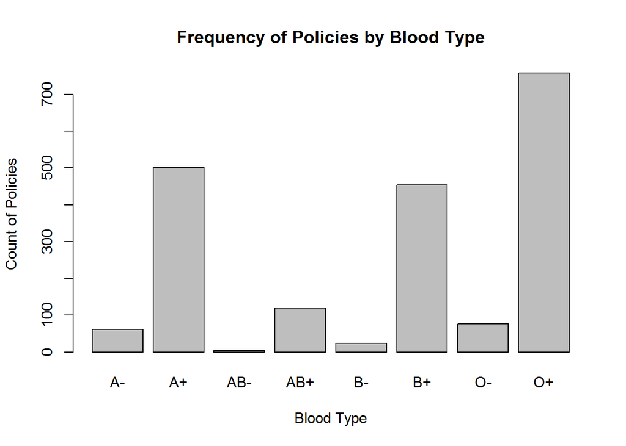

Question: Which blood type is most common?

### Problem 2: Visualizing One Numeric Variable

4. Create a dot plot of height (Centimeters)

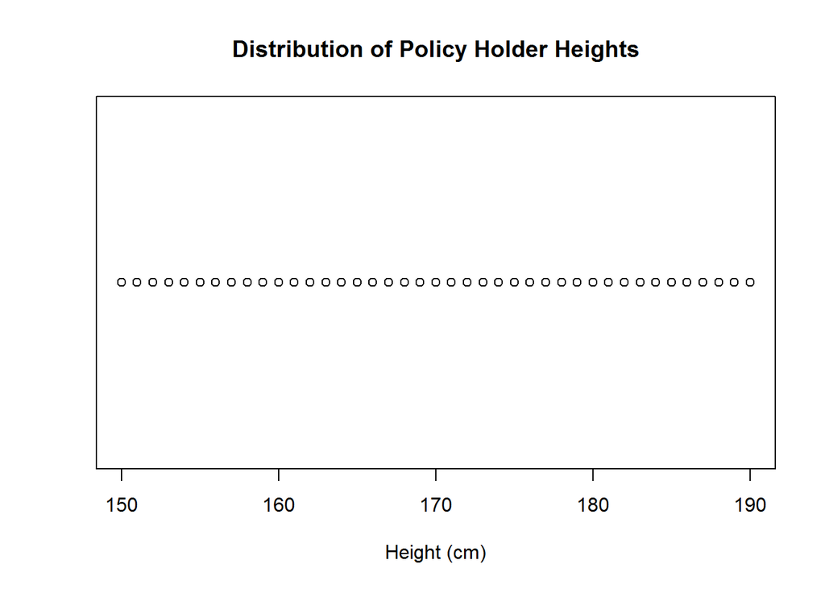

5. Create a boxplot of height (Centimeters)

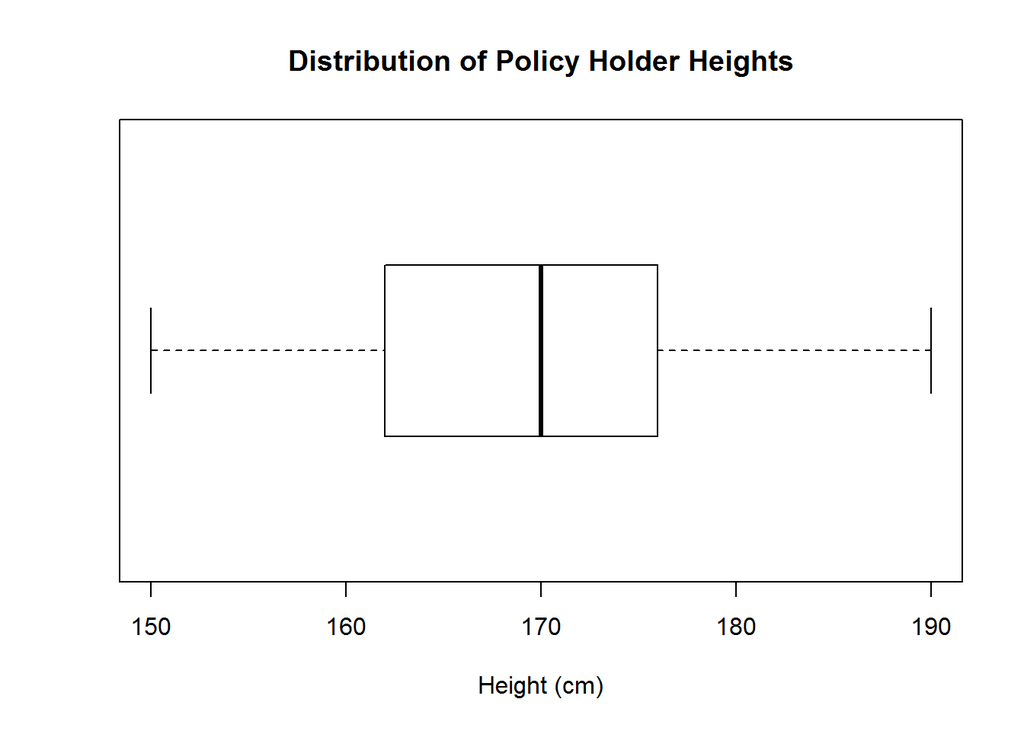

6. Create a histogram of height (Centimeters)

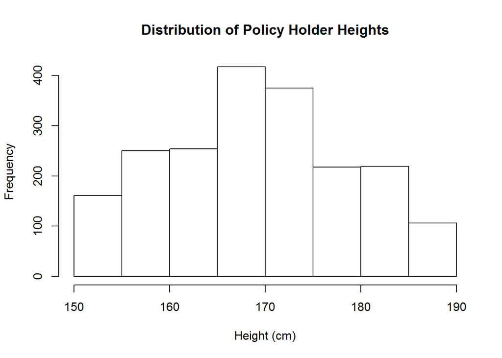

7. Create a density plot of height (Centimeters)

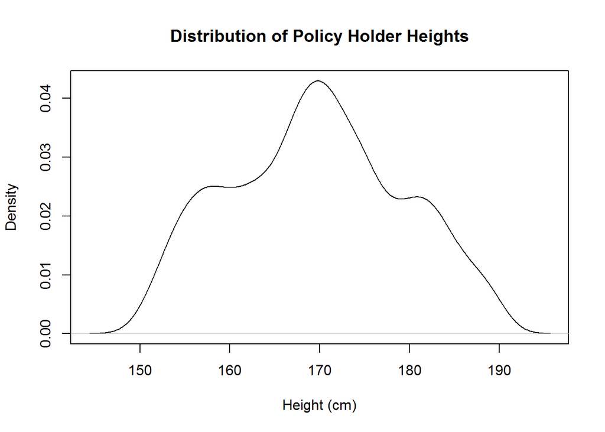

Question: Is this distribution roughly symetric?

### Problem 3: Visualizing Two Categorical Variables

8. Create a spineplot of Blood Type and Gender

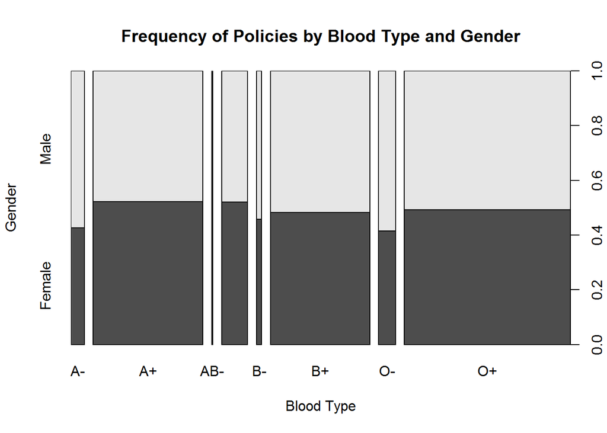

9. Create a mosaic plot of blood type and gender

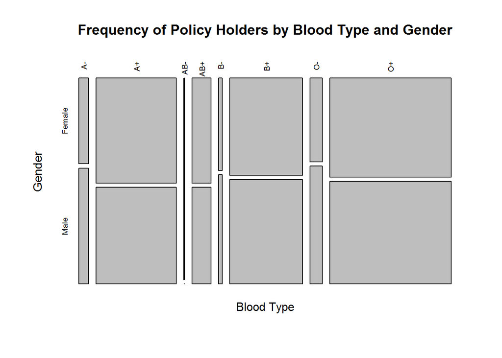

Question: What appears to be the least common blood type for males?

### Problem 4: Visualizing Two Numeric Variables

10. Create a scatterplot of weight (Kilograms) and height (Centimeters)

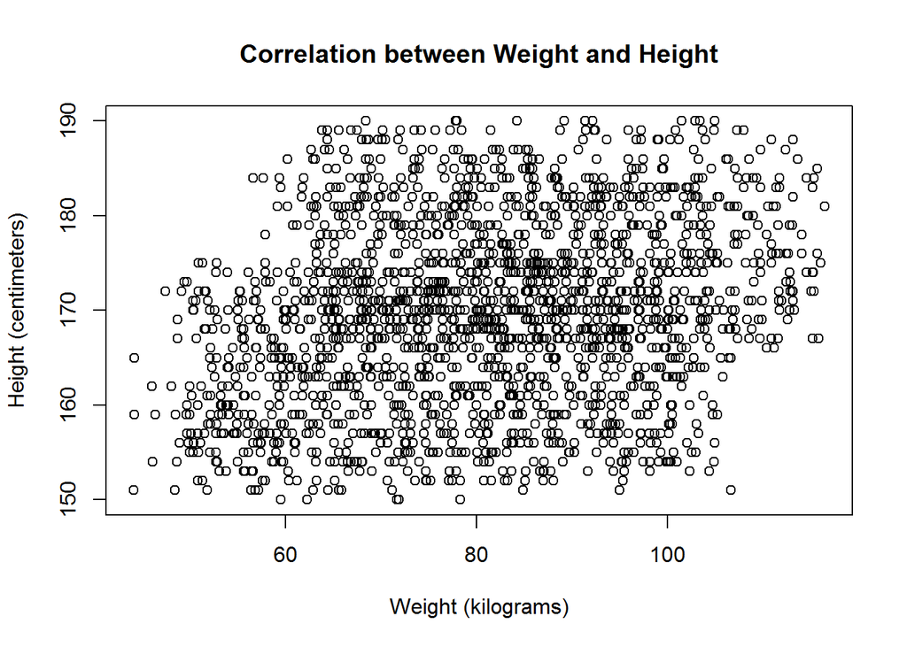

11. Create a scatterplot of Rate and Age

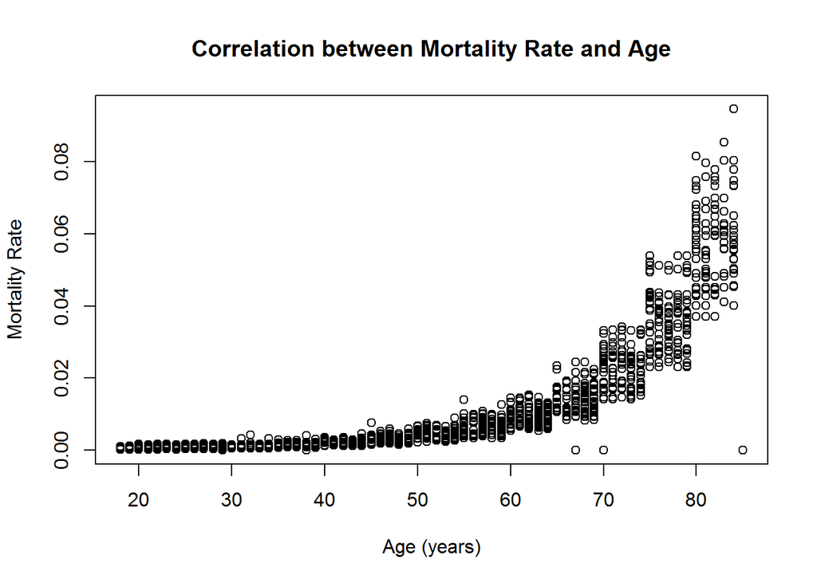

Question: Does there appear to be any pattern in either of these plots?

### Problem 5: Visualize a Time Series

12. Plot a line graph of mortality rate by age  
    *NOTE: We’re using Age as proxy for a time variable (i.e.Date of Birth)*  
    *NOTE: Create the array using tapply first, then set x to the names and y to the values*

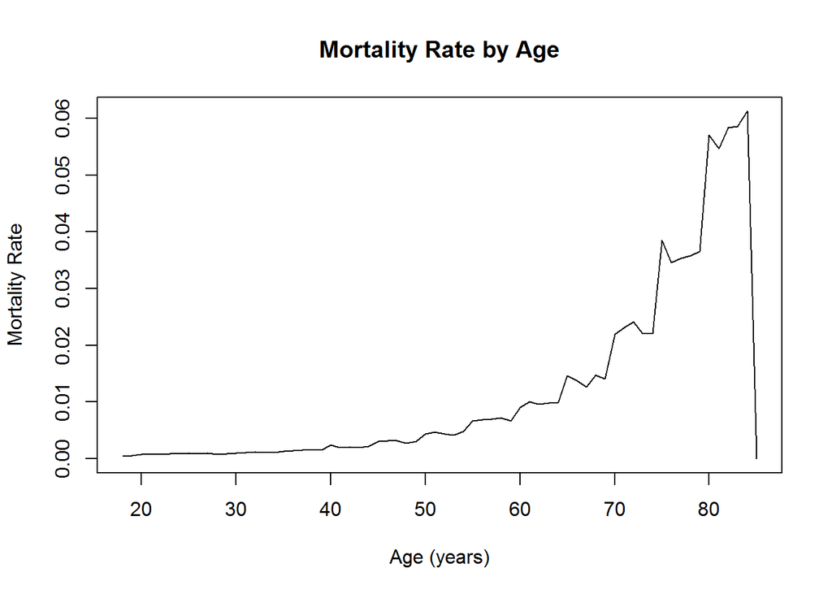

Question: Why is there a steep decline at 85?

### Problem 6: Visualizing a Numeric Variable Grouped By a Categorical Variable

13. Create a bar graph of Rate by Gender

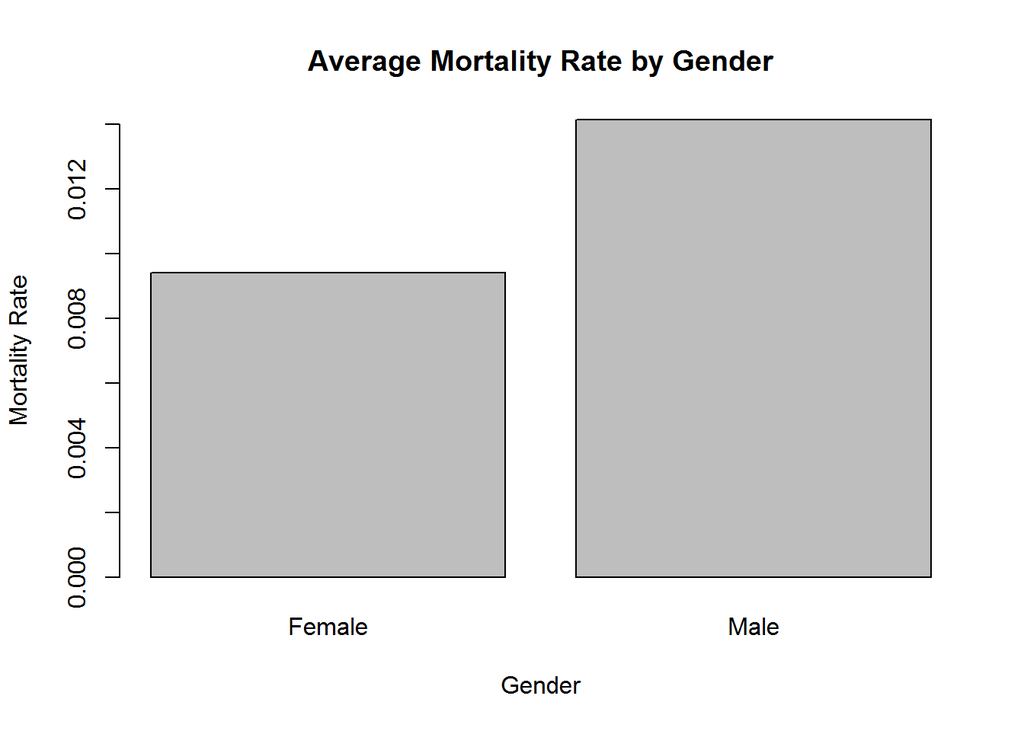

14. Create a bar graph of average Height by Blood Type

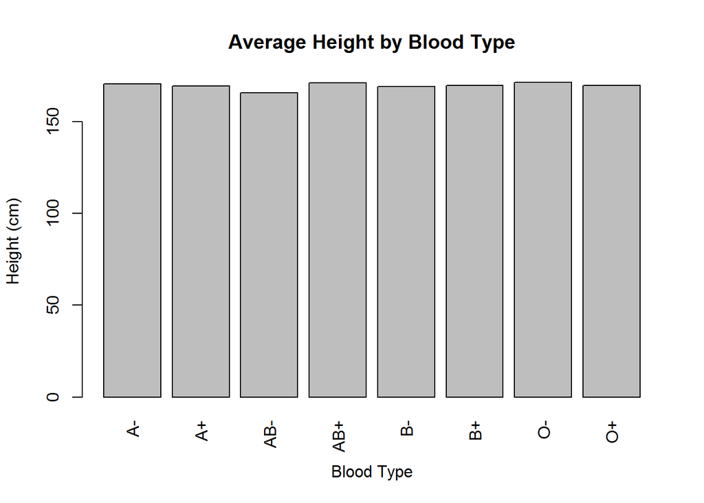

Question: How are blood type and height related?

### Problem 7: Visualizing Many Variables

15. Create a scatterplot matrix of Age, Kilograms, Centimeters, and Rate

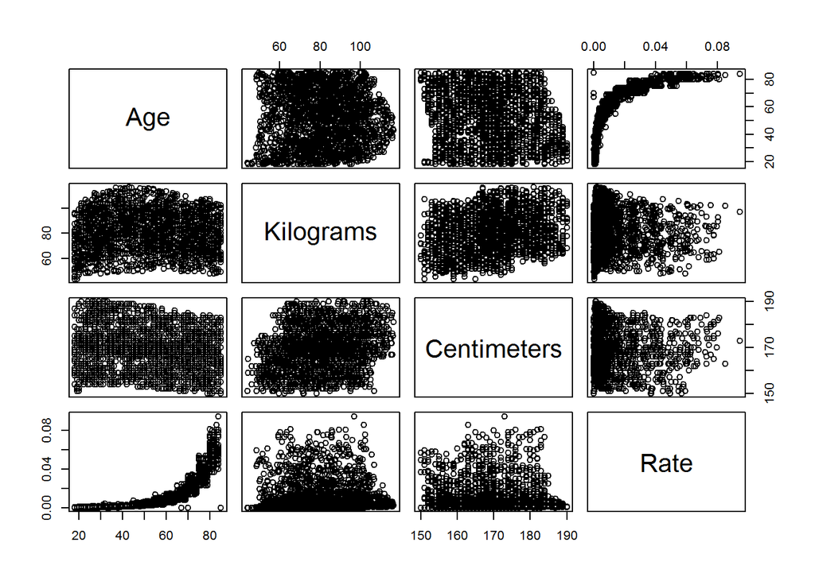

16. Load corrgram package
17. Create a correlogram of Age, Kilograms, Centimeters, and Rate

[figure not shown]

Question: Which two variables have the strongest correlation?